# U.S. High School Girls Memory and Language

- Show All Code
- Hide All Code

Course MATH 325

Author

Lexi Soelberg

```r
library(tidyverse)
library(DT)
library(pander)
library(readr)
library(plotly)
library(car)


HSS <- read_csv("../../data/HighSchoolSeniors.csv")
#If this code does not work:
#Use the top menu from RStudio's window to select "Session, Set Working Directory, To Source File Location", and then play this R-chunk into your console to read the HSS data into R.

## In your Console run View(HSS) to ensure the data has loaded correctly.
```

## Background

A [2022 U.S. census at school questionnaire](https://ww2.amstat.org/censusatschool/pdfs/C@SQuestionnaire.pdf) gathered data from 500 high schoolers from 15 states. With 40 questions there are a lot of options available for the study. One of the criteria was on if the students can hold a conversation in 1 language or more than one. As someone who fluently speaks two languages I wanted to see if language has an effect on memory. Students were also asked to perform a memory test and report in how many seconds they uncovered the matching pairs. To narrow it in, I also wanted to just look at female students. With all this in mind my hypothesis is:

**Is there a difference in memory scores of female students who speak 2 or more languages than female students who only speak 1 language?**

$$H_0: \mu_\text{1 language} = \mu_\text{2+ langugages}$$

$$H_a: \mu_\text{1 language} \ne \mu_\text{2+ langugages}$$

Significance level is

$$\alpha = 0.05$$

```r
HSSF <- select(HSS, Languages_spoken, Gender, ClassGrade, Ageyears, Region, Score_in_memory_game) %>%
  filter(Gender == "Female")
HSSF <- HSSF %>%
  filter(Languages_spoken != 0)
HSSF <- HSSF %>%
  mutate(
    SpokenLanguages = case_when(
      Languages_spoken %in% c(1, 1.5) ~ "1 language",
      Languages_spoken %in% c(2, 3, 4, 5) ~ "2 or more languages",
      TRUE ~ "Not specified"
    )
  )
HSSF <- HSSF %>%
  filter(complete.cases(select(., Languages_spoken, Score_in_memory_game)))

HSSF <- HSSF %>%
  filter(complete.cases(select(., Languages_spoken, Score_in_memory_game))) %>%
  mutate(
    ClassGrade = case_when(
      ClassGrade == 9 ~ "Freshman",
      ClassGrade == 10 ~ "Sophomore",
      ClassGrade == 11 ~ "Junior",
      ClassGrade == 12 ~ "Senior"
    )
  )
HSSF <- HSSF %>%
  rename(
    SchoolYear = ClassGrade,
    Age = Ageyears,
    State = Region,
    MemoryScore = Score_in_memory_game,
    Languages = Languages_spoken,
    Speaks = SpokenLanguages
  ) %>%
  select(
    Speaks,
    Languages,
    MemoryScore,
    SchoolYear,
    Age,
    State
  )
```

#### High School Girls

```r
datatable(HSSF,
          options=list(scrollX= TRUE,
          lengthMenu = c(5, 10, 15)),
          extensions="Responsive")
```

|  | Speaks | Languages | MemoryScore | SchoolYear | Age | State |
| --- | --- | --- | --- | --- | --- | --- |
| 1 | 1 language | 1 | 46 | Senior | 17 | GA |
| 2 | 2 or more languages | 2 | 43 | Junior | 15 | NC |
| 3 | 1 language | 1 | 61 | Senior | 17 | CO |
| 4 | 2 or more languages | 2 | 49 | Junior | 18 | SC |
| 5 | 1 language | 1 | 44 | Junior | 16 | WA |
| 6 | 1 language | 1 | 44 | Senior | 17 | WA |
| 7 | 1 language | 1 | 50 | Senior | 17 | WA |
| 8 | 1 language | 1 | 44 | Freshman | 14 | GA |
| 9 | 2 or more languages | 2 | 32 | Senior | 18 | GA |
| 10 | 1 language | 1 | 64 | Junior | 18 | SC |

[output cut: 214 more lines]

## Analysis

```r
plot_ly(data = HSSF,
        type = "box") %>%
  add_trace(
    y = ~MemoryScore[Speaks == "1 language"],
    name = "Speaks 1 Language",
    fillcolor = "indianred1",
    line = list(color = "indianred4", width = 4),
    marker = list(color = "indianred", line = list(color = "darkgray", width = 1))
  ) %>%
  add_trace(
    y = ~MemoryScore[Speaks == "2 or more languages"],
    name = "Speaks 2 or More Languages",
    fillcolor = "steelblue1",
    line = list(color = "steelblue4", width = 4),
    marker = list(color = "steelblue", line = list(color = "darkgray", width = 1))
  ) %>%
  layout(
    title = "Memory Proficiency Based on Language Competency",
    yaxis = list(title = "Memory Score (seconds)"),
    xaxis = list(title = "High School Girls Language Mastery")
  )
```

[interactive chart not shown]

Hovering over the plots shows the quantile data and below the values are shown. The sample size for both is also shown. 138 for 1 language and 86 for 2 or more languages. We can see a tighter standard deviation but lower mean for the girls that speak 2 or more languages.

#### Memory Score Summary Table

```r
HSSF %>%
  group_by(Speaks) %>%
  summarise(
    Min = min(MemoryScore, na.rm = TRUE),
    Q1 = quantile(MemoryScore, 0.25, na.rm = TRUE),
    Med = median(MemoryScore, na.rm = TRUE),
    Q3 = quantile(MemoryScore, 0.75, na.rm = TRUE),
    Max = max(MemoryScore, na.rm = TRUE),
    Average = mean(MemoryScore, na.rm = TRUE),
    StDev = sd(MemoryScore, na.rm = TRUE),
    SampleSize = n()
  ) %>%
  pander()
```

| Speaks | Min | Q1 | Med | Q3 | Max | Average | StDev | SampleSize |
| --- | --- | --- | --- | --- | --- | --- | --- | --- |
| 1 language | 0.312 | 39 | 45 | 52 | 79 | 46.3 | 10.88 | 138 |
| 2 or more languages | 18 | 38 | 43 | 49 | 62 | 42.38 | 9.618 | 86 |

Using an independent samples t.test the true differences in the means will be tested. First, the normality of the distributions is shown using Q-Q Plots.

#### Q-Q Plots

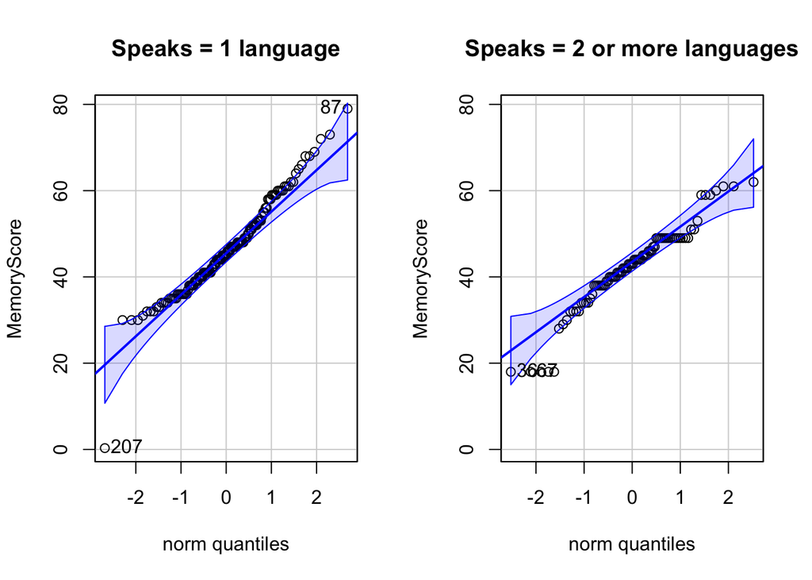

```r
car::qqPlot(MemoryScore ~ Speaks, data = HSSF, main = "Q-Q Plot of Memory Score by Language")
```

The data for both is approximately normal, with a low outlier in the 1 language group. Proceeding to a t.test:

#### T.Test Stats

```r
t.test(MemoryScore ~ Speaks, data=HSSF, mu=0)%>%
  pander()
```

Welch Two Sample t-test: `MemoryScore` by `Speaks` (continued below)

| Test statistic | df | P value | Alternative hypothesis |
| --- | --- | --- | --- |
| 2.816 | 197 | 0.005361 * * | two.sided |

| mean in group 1 language | mean in group 2 or more languages |
| --- | --- |
| 46.3 | 42.38 |

An independent samples t-test found a significantly higher average memory score speed of girls who speak 1 language compared to girls who speak 2 or more t(197)= 2.816, p = 0.005361<$\alpha$

There is sufficient evidence to **reject the null hypothesis**.

## Interpretation

We can see that from this there is a difference in the average memory test speed. The two sided t-test demonstrates that the means are 42.38 seconds for the girls who speak 2+ languages, and 46.3 seconds for the girls who speak 1 language.

On average, that is a 4 seconds discrepancy, and with a p-value of 0.0054 we have sufficient evidence proving that the 4 second difference in the means is actually significant.

We can then conclude that girls who speak 2 languages have a quicker memory than those who speak 1.

##### Credits

I would like to credit ChatGPT for checking my codes, Brother Saunders for doing the same, my classmate for believing in me, and the previous student analyses for giving me direction in the layout of my analysis.

Back to top